# Text Mining, Introduction

Hamza Saadi

September 20, 2018

[figure not shown]

After the EDA that have been made by @Mohamed_Yacine_Smail on both data from [lkeria](https://www.lkeria.com/) and [ouedkniss](https://www.ouedkniss.com/immobilier) in part II, now will see a different type of analysis which is text mining

## Introduction:

From year to year it has become imperative for an organization to have a structure in place to mine actionable insights from the text being generated. From social media analytics to risk management and cybercrime protection, dealing with text data has never been more important.

In this article we will discuss different methods and techniques used in textming, starting with some basic techniques which will lead into advanced text mining methodes as natural language processing also learning about pre-processing of the text data in order to extract better features from clean data.

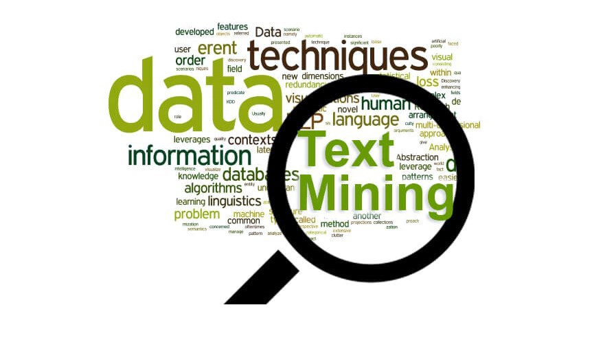

## Procedure:

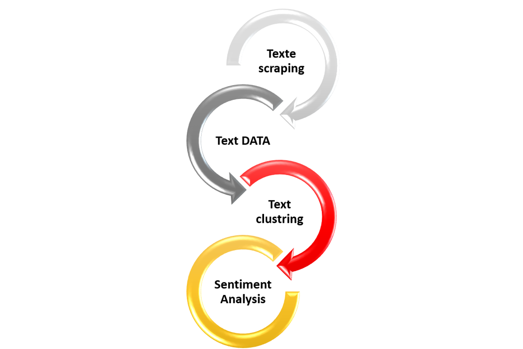